# Google Data Analytics Case Study - Cyclistic Bike Share

Liong Teng Lap

2023-01-12

# Introduction

The following case study sets the scene where I am working as a junior data analyst in the marketing analytics team at a bike share company in Chicago named Cyclistic.

The stakehholders involved are:

- The director of marketing and my manager: responsible for the development of campaigns and initiatives to promote the bike-sharing program, which may include email, social media and other channels.
- Cyclistic executive team: Detail-oriented executive team that decides the approval of recommended marketing program.

The director of marketing believes that the company’s future success depends on **maximizing the number of annual memberships**. Hence, the marketing analytics team are tasked to understand how casual riders and annual members use Cyclistic bikes differently and design a new marketing strategy to convert casual riders into annual members.

The data analysis life cycle used for the case study are made up of 6 phases:

- Phase 1: **ASK**
  - Define problem to solve.
- Phase 2: **PREPARE**
  - Collect, manage and organize data for upcoming analysis process.
- Phase 3: **PROCESS**
  - Clean data to eliminate error and inaccuracies.
- Phase 4: **ANALYZE**
  - Discover relationships and patterns in data.
- Phase 5: **SHARE**
  - Summarize findings and create data visualization to better understand findings.
- Phase 6: **ACT**
  - Provide recommendations based on insights so stakeholder can make better informed decisions.

# Phase 1: **ASK**

Business goal: Design marketing strategies aimed at converting casual riders into annual members

Questions asked to guide future marketing program:

- How do annual and member riders use Cyclistic bikes differently?
  - When are casual and member riders most active?
  - Which is the preferred bike among users?
  - Where do users ride to the most?

With the insights obtain, the following questions would be:

- Why would casual riders buy Cyclistic annual membership?
- How can Cyclistic use digital media to influence casual riders to member riders?

# Phase 2: **PREPARE**

## 1. Data Organization

There are 12 CSV files where each CSV file represent a month of the Cyclistic bike share dataset, starting from Dec-2021 to Nov-2022.

Since the CSV files are huge, with more than 200,000 rows of data each file, all the CSV files were stored in the BigQuery database in the form of table. Working with SQL instead of Spreadsheet for huge dataset will be more efficient where data can be cleaned and transformed in a faster and easier manner.

Shown in the diagram below, the monthly tables are stored in the **cyclistic_dataset**.

[figure not shown]

## 2. Data Source credibility

The dataset used for Cyclistic, a fictional company, is an open data made by Motivate International Inc., under this [license](https://www.divvybikes.com/data-license-agreement). The data is unbias as it is inclusive of sample group from people with disabilities and is representative of the population as a whole.

# Phase 3: **PROCESS**

## 1. Cleaning & Transforming data with SQL BigQuery

Data cleaning is important as dirty data will cause inaccurate analysis. Generally, there are 5 types of dirty data, such as :

- Duplicate data
- Outdated data
- Missing data (NULLS)
- Incorrect data
- Inconsistent data

The data cleaning process will be tackling each of the dirty data.

### 1.1. NULL Checking using SQL Query

The NULL checking process was done using the Jan_22 table where NULLS were identified for start_station_name and end_station_name.

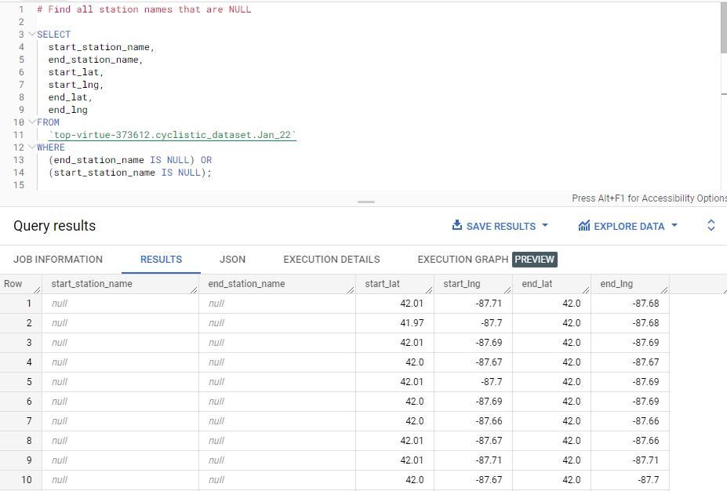

Hence, a few sample of the start_station_name’s and end_station_name’s coordinate (start_lat, start_lng) and (end_lat, end_lng) were used to test if the station names can be retrieved using the coordinates.

#### 1.1.1. start_station_name tracking

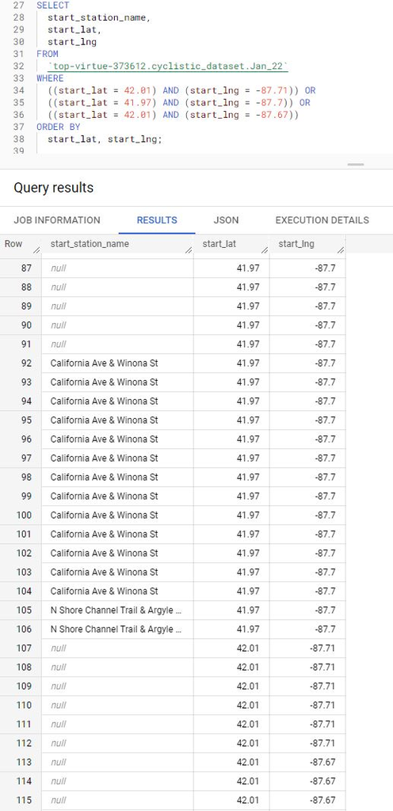

#### 1.1.2. end_station_name tracking

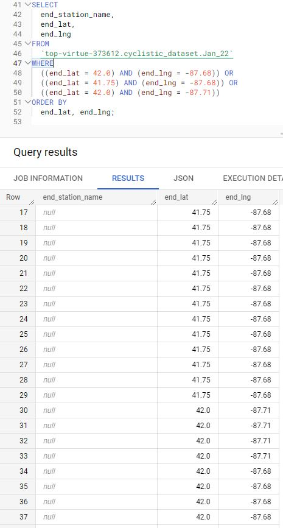

#### 1.1.3. start_station_name & end_station_name tracking findings, & NULL deletion decision

From the start_station_name NULL check, it is shown that Most of the station names with the stated coordinates remain NULL except for (41.97, -87.7) which shows 3 different station names:

- NULL
- California Ave & Winona St
- N Shore Channel Trail & Argyle Ave

The same coordinate returned 3 inconsistent results. This may be due to:

- The stated coordinate is a small area which may consist of several station
- Bikes that were used without station’s name (NULL) may be due to the bike being parked at inappropriate location, not by the station.

Since the business task is to create a marketing strategy to convert casual riders to members, having a station name may be important for advertising purposes, hence, observations with NULL station names shall be deleted as part of the cleaning process.

### 1.2. Table combination, field selection & cleaning

The query shown below combines all relevant table into a bigger table to be cleaned and transformed. As concluded previously, NULL station names will be filtered out from the combined table, DISTINCT function to eliminate duplicate data, and additional field such as **ride_duration_sec** and **day_of_week** will be added for analysis usage.

With the above query, the data is free from:

- Duplicate data
- Missing data
- Outdated data (since it is a 1 year time-bound analysis)

The rest of the data checking and cleaning will be done in section 2 with R.

[figure not shown]

### 1.3. Data organization for Clean data

The table executed from the query in section 2.2 is then stored in a seperate dataset named **Cyclistic_clean_dataset** with the table name **Dec21_to_Nov22_R1**.

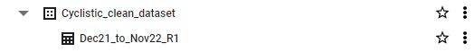

## 2. Further data checking & cleaning with RStudio

### 2.1. Load required libraries

In order to extract and use the dataset from BigQuery, the *bigrquery* package was used to link RStudio with BigQuery. The rest of the packages are used for data manipulation & data cleaning.

```r
library(bigrquery)
library(tidyverse)
library(janitor)
library(lubridate)
library(hms)
```

### 2.2. Accessing BigQuery with R

Since the dataset is huge with about 4.4 million observations, it was decided to store the dataset in BigQuery database table rather than downloading it locally as it will be less efficient working with a CSV file this large.

Hence, in order to access the dataset from BigQuery, the code below are used to connect RStudio with BigQuery.

*Note that this is the 1st revision of the dataset after data cleaning*.

**Table name :** Dec21_to_Nov22_R1

```r
# Link R with BigQuery Project ID
projectid = "top-virtue-373612"

# Set query
sql <- "SELECT * FROM `top-virtue-373612.Cyclistic_clean_dataset.Dec21_to_Nov22_R1`"

# Store BigQuery table in a variable
bikeshare <- bq_project_query(projectid, sql)
```

[output not shown]

[output not shown]

[output not shown]

[output not shown]

```r
# Download dataset
biketrip_tb <- bq_table_download(bikeshare)
```

### 2.3. First glimpse into the data

The following functions head(), str() and summary() are used to further check if the data is correctly imported, data formatting and identify the presence of the remaining dirty data such as:

- Inconsistent data
- Inaccurate data

#### 2.3.1. Showing 1st 10 rows of the imported data of Dec21_to_Nov22_R1

```r
biketrip_tb %>%
  arrange(started_at) %>%
  head(10)
```

```
## # A tibble: 10 × 9
##    ride_id       ridea…¹ started_at          ended_at            ride_…² start…³
##    <chr>         <chr>   <dttm>              <dttm>                <int> <chr>
##  1 0CD83C3FE35E… classi… 2021-12-01 00:00:03 2021-12-01 00:07:34     451 Wednes…
##  2 5CB387082B43… classi… 2021-12-01 00:03:44 2021-12-01 00:07:44     240 Wednes…
##  3 A8830C276991… classi… 2021-12-01 00:04:31 2021-12-01 00:07:37     186 Wednes…
##  4 5888E624121F… electr… 2021-12-01 00:05:32 2021-12-01 00:19:18     826 Wednes…
##  5 82CE2ACCE16E… classi… 2021-12-01 00:05:47 2021-12-01 00:32:52    1625 Wednes…
##  6 D83AD6373B1F… classi… 2021-12-01 00:06:35 2021-12-01 00:18:47     732 Wednes…
##  7 A31FD6711E68… classi… 2021-12-01 00:06:52 2021-12-01 00:11:38     286 Wednes…
##  8 06A16235908F… classi… 2021-12-01 00:06:52 2021-12-01 00:11:39     287 Wednes…
##  9 04C29F246901… classi… 2021-12-01 00:07:45 2021-12-01 00:26:46    1141 Wednes…
## 10 745DAE8B4281… electr… 2021-12-01 00:08:38 2021-12-01 00:23:40     902 Wednes…
## # … with 3 more variables: start_station_name <chr>, end_station_name <chr>,
## #   member_casual <chr>, and abbreviated variable names ¹rideable_type,
## #   ²ride_duration_sec, ³start_day_of_week
```

#### 2.3.2. Checking data frame internal structure of Dec21_to_Nov22_R1

```r
str(biketrip_tb)
```

```
## tibble [4,410,328 × 9] (S3: tbl_df/tbl/data.frame)
##  $ ride_id           : chr [1:4410328] "DB3A30058E7EBEE4" "189B09BA13E85B81" "F842798715E08F2D" "4CDEDAEF34CB0612" ...
##  $ rideable_type     : chr [1:4410328] "docked_bike" "docked_bike" "docked_bike" "docked_bike" ...
##  $ started_at        : POSIXct[1:4410328], format: "2021-12-01 08:10:11" "2021-12-01 10:51:36" ...
##  $ ended_at          : POSIXct[1:4410328], format: "2021-12-02 09:52:41" "2021-12-01 11:02:28" ...
##  $ ride_duration_sec : int [1:4410328] 92550 652 2038 5453 1677 1853 1223 4312 628 377 ...
##  $ start_day_of_week : chr [1:4410328] "Wednesday" "Wednesday" "Wednesday" "Wednesday" ...
##  $ start_station_name: chr [1:4410328] "Halsted St & 35th St" "Canal St & Monroe St" "Franklin St & Jackson Blvd" "Clark St & Ida B Wells Dr" ...
##  $ end_station_name  : chr [1:4410328] "Halsted St & 35th St" "Michigan Ave & Ida B Wells Dr" "Shedd Aquarium" "Sheridan Rd & Montrose Ave" ...
##  $ member_casual     : chr [1:4410328] "casual" "casual" "casual" "casual" ...
```

Result shows that the structure of the data are accurate and that all 4410328 rows of observations are imported.

#### 2.3.3. Summary of Dec21_to_Nov22_R1

```r
summary(biketrip_tb)
```

```
##    ride_id          rideable_type        started_at
##  Length:4410328     Length:4410328     Min.   :2021-12-01 00:00:03.00
##  Class :character   Class :character   1st Qu.:2022-05-19 12:16:21.25
##  Mode  :character   Mode  :character   Median :2022-07-12 22:15:29.00
##                                        Mean   :2022-07-06 09:09:46.56
##                                        3rd Qu.:2022-09-06 15:55:33.25
##                                        Max.   :2022-11-30 23:56:11.00
##     ended_at                      ride_duration_sec start_day_of_week
##  Min.   :2021-12-01 00:07:34.00   Min.   : -10122   Length:4410328
##  1st Qu.:2022-05-19 12:34:16.00   1st Qu.:    364   Class :character
##  Median :2022-07-12 22:32:15.50   Median :    637   Mode  :character
##  Mean   :2022-07-06 09:26:56.10   Mean   :   1030
##  3rd Qu.:2022-09-06 16:09:59.25   3rd Qu.:   1143
##  Max.   :2022-12-01 11:45:53.00   Max.   :2061244
##  start_station_name end_station_name   member_casual
##  Length:4410328     Length:4410328     Length:4410328
##  Class :character   Class :character   Class :character
##  Mode  :character   Mode  :character   Mode  :character
##
##
##
```

From the summary, it was found that the :

1. The minimum ride duration is in negative value, -10122.
2. The maximum ride duration is 2061244 seconds, which is about 572.6 hours.

The dataset was further cleaned using R by: * Filtering out negative ride duration. * Filtering out ride_duration_sec that is more than 86400 assuming a 1-day pass is a 24-hour pass. (24 hours = 86400 seconds)

```r
biketrip_tb_r1 <- biketrip_tb %>%
  filter(ride_duration_sec > 0) %>%
  filter(ride_duration_sec <= 86400)
```

```r
head(biketrip_tb_r1)
```

```
## # A tibble: 6 × 9
##   ride_id        ridea…¹ started_at          ended_at            ride_…² start…³
##   <chr>          <chr>   <dttm>              <dttm>                <int> <chr>
## 1 189B09BA13E85… docked… 2021-12-01 10:51:36 2021-12-01 11:02:28     652 Wednes…
## 2 F842798715E08… docked… 2021-12-01 11:06:08 2021-12-01 11:40:06    2038 Wednes…
## 3 4CDEDAEF34CB0… docked… 2021-12-01 11:43:49 2021-12-01 13:14:42    5453 Wednes…
## 4 D9538145D03FE… docked… 2021-12-01 12:21:04 2021-12-01 12:49:01    1677 Wednes…
## 5 2096ED25E6BEA… docked… 2021-12-01 13:30:14 2021-12-01 14:01:07    1853 Wednes…
## 6 5891372B49465… docked… 2021-12-01 13:33:54 2021-12-01 13:54:17    1223 Wednes…
## # … with 3 more variables: start_station_name <chr>, end_station_name <chr>,
## #   member_casual <chr>, and abbreviated variable names ¹rideable_type,
## #   ²ride_duration_sec, ³start_day_of_week
```

```r
summary(biketrip_tb_r1)
```

```
##    ride_id          rideable_type        started_at
##  Length:4409838     Length:4409838     Min.   :2021-12-01 00:00:03.00
##  Class :character   Class :character   1st Qu.:2022-05-19 12:19:29.25
##  Mode  :character   Mode  :character   Median :2022-07-12 22:16:47.50
##                                        Mean   :2022-07-06 09:12:26.72
##                                        3rd Qu.:2022-09-06 15:55:46.00
##                                        Max.   :2022-11-30 23:56:11.00
##     ended_at                      ride_duration_sec start_day_of_week
##  Min.   :2021-12-01 00:07:34.00   Min.   :    1     Length:4409838
##  1st Qu.:2022-05-19 12:37:09.25   1st Qu.:  364     Class :character
##  Median :2022-07-12 22:34:24.50   Median :  637     Mode  :character
##  Mean   :2022-07-06 09:29:26.25   Mean   : 1020
##  3rd Qu.:2022-09-06 16:10:19.00   3rd Qu.: 1143
##  Max.   :2022-12-01 11:45:53.00   Max.   :86362
##  start_station_name end_station_name   member_casual
##  Length:4409838     Length:4409838     Length:4409838
##  Class :character   Class :character   Class :character
##  Mode  :character   Mode  :character   Mode  :character
##
##
##
```

Summary result from table **biketrip_tb_r1** shows that:

1. The minimum ride_duration_sec is 1s, no longer negative value.
2. The maximum ride_duration_sec is 86362s, which meets the criteria of maximum 24 hours 1-day pass.

The processed data is ready to be used for analysis.

# Phase 4 & 5: **ANALYZE & SHARE**

To start it off, the customer base of Cyclistic bike share was analyzed to find out how many users are there, in terms of member riders and casual riders.

```r
total_users <- biketrip_tb_r1 %>%
  group_by(member_casual) %>%
  summarise(rider_count = n())

head(total_users)
```

```
## # A tibble: 2 × 2
##   member_casual rider_count
##   <chr>               <int>
## 1 casual            1771453
## 2 member            2638385
```

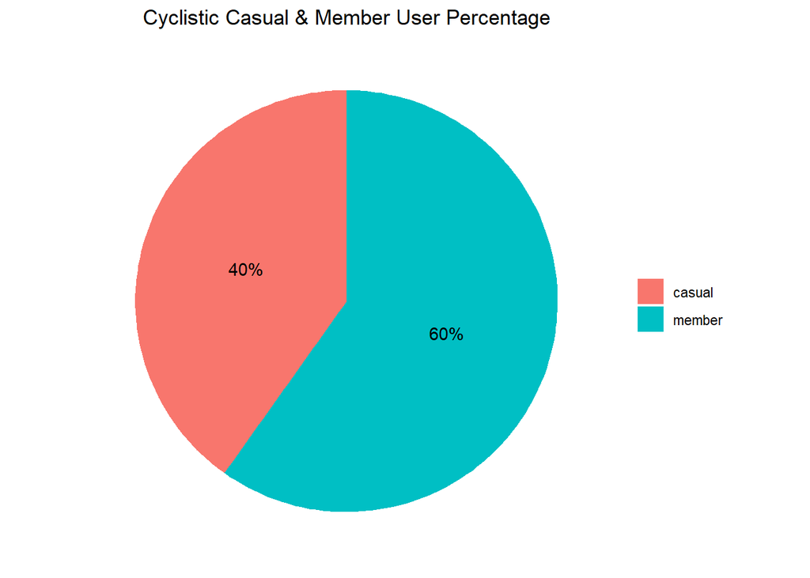

```r
total_users %>%
  ggplot(aes(x = "", y = rider_count, fill = member_casual)) +
  geom_bar(stat = "identity", width = 1) +
  coord_polar("y", start = 0) +
  geom_text(aes(label = paste0(round(rider_count/sum(rider_count)*100), "%")), position = position_stack(vjust = 0.5)) +
  scale_fill_manual(values = c("#F8766D", "#00BFC4")) +
  labs(x = NULL, y = NULL, fill = NULL, title = "Cyclistic Casual & Member User Percentage") +
  theme_classic() +
  theme(axis.line = element_blank(),
        axis.text = element_blank(),
        axis.ticks = element_blank(),
        plot.title = element_text(hjust = 0.5))
```

It was found that majority of the customers are already subscribed as a member with 60% member riders and 40% unsubscribed casual riders. In order to achieve the business objective of converting more casual riders to member riders, the dataset was further explored to better understand the users behavior.

Generally, the main question for this analysis is to answer **“How are annual members and casual riders using Cyclistic bikes differently?”**, which would then lead to more informed decision on designing the right strategy of increasing membership subscription. Hence, to draw a conclusion for the main question, 3 of the following questions were analyzed to justify the main question:

- When are casual and member riders most active?
- Which is the preferred bike among users?
- Where do users ride to the most?

## 1. When are casual & member riders most active?

### Chart 1.1: Count of Riders throughout the Week

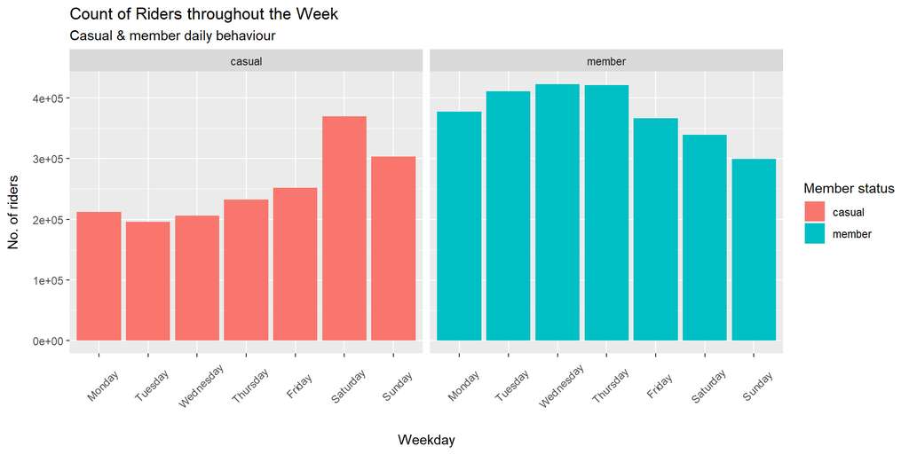

```r
biketrip_tb_r1 %>%
  ggplot() +
  geom_bar(mapping = aes(x = factor(start_day_of_week, c("Monday","Tuesday","Wednesday","Thursday","Friday","Saturday","Sunday")),
                         fill = member_casual)) +
  facet_wrap(~member_casual) +
  theme(axis.text.x = element_text(angle = 45, margin = margin(t = 20)),
        axis.title.y = element_text(margin = margin(r = 10))) +
  labs(title = "Count of Riders throughout the Week",
       subtitle = "Casual & member daily behaviour",
       fill = "Member status") +
  xlab("Weekday") +
  ylab("No. of riders")
```

### Chart 1.2: Daily Count of Riders Each Month throughout the Year

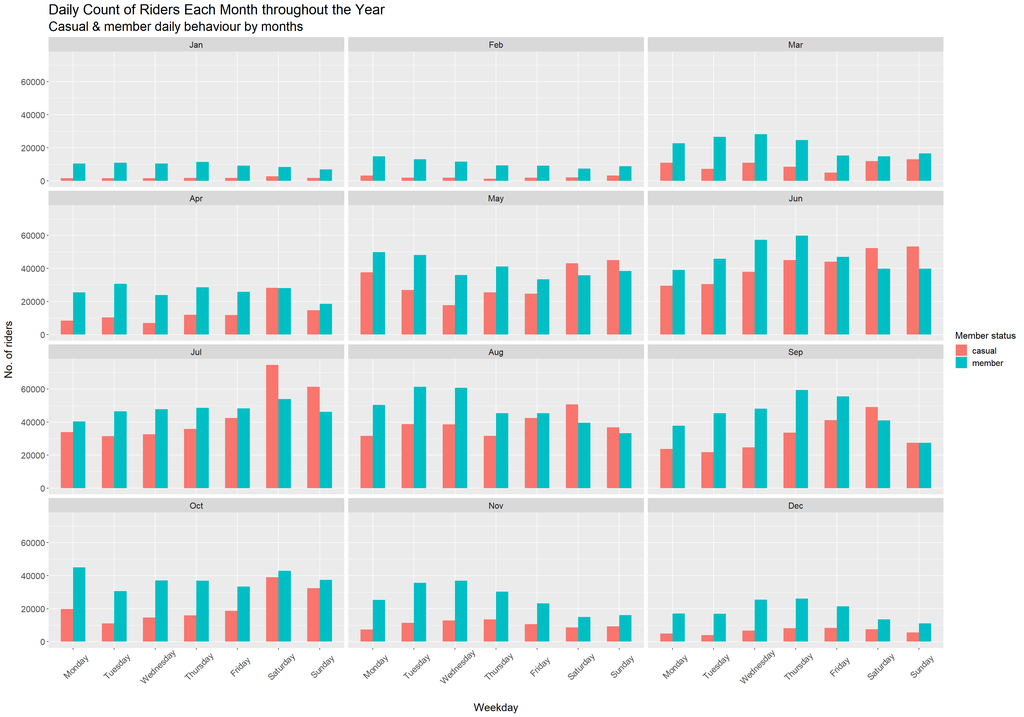

```r
biketrip_tb_r1 %>%
  ggplot() +
  geom_bar(mapping = aes(x = factor(start_day_of_week, c("Monday","Tuesday","Wednesday","Thursday","Friday","Saturday","Sunday")), fill = member_casual),
           width = 0.6,
           position = "dodge") +
  facet_wrap(~month(ymd_hms(biketrip_tb_r1$started_at), label = TRUE), ncol = 3) +
  theme(axis.text.x = element_text(angle = 45, margin = margin(t = 20)),
        axis.text = element_text(size = 12),
        axis.title = element_text(size = 15),
        axis.title.y = element_text(margin = margin(r = 10)),
        strip.text = element_text(size = 12),
        plot.title = element_text(size = 20),
        plot.subtitle =  element_text(size = 18),
        legend.title = element_text(size = 13),
        legend.text = element_text(size = 12)) +
  labs(title = "Daily Count of Riders Each Month throughout the Year",
       subtitle = "Casual & member daily behaviour by months",
       fill = "Member status") +
  xlab("Weekday") +
  ylab("No. of riders")
```

From Chart 1.1 and 1.2, it is shown that casual riders uses the bike share service most during Saturdays and Sundays, whereas member riders are more active during the weekdays. This may be due to **casual riders uses the service more for leisure or sightseeing during the weekends whereas member riders uses it to commute to work on the weekdays**.

To justify the assumption where casual riders uses the service for leisure and member riders for commuting, the relationship between the start time and the dataset was manipulated to add another column **start_time_hr** to fold the time where user start using the bike in hour, to observe at which time of the day is the bike share service most active between casual and member riders throughout the week.

```r
# Adding another field to store start time(hour)

biketrip_tb_r1_time <- biketrip_tb_r1 %>%  #manipulated table to be stored in biketrip_tb_r2_time
  mutate(start_time_hr = hour(ymd_hms(biketrip_tb_r1$started_at)))

head(biketrip_tb_r1_time,10)
```

```
## # A tibble: 10 × 10
##    ride_id       ridea…¹ started_at          ended_at            ride_…² start…³
##    <chr>         <chr>   <dttm>              <dttm>                <int> <chr>
##  1 189B09BA13E8… docked… 2021-12-01 10:51:36 2021-12-01 11:02:28     652 Wednes…
##  2 F842798715E0… docked… 2021-12-01 11:06:08 2021-12-01 11:40:06    2038 Wednes…
##  3 4CDEDAEF34CB… docked… 2021-12-01 11:43:49 2021-12-01 13:14:42    5453 Wednes…
##  4 D9538145D03F… docked… 2021-12-01 12:21:04 2021-12-01 12:49:01    1677 Wednes…
##  5 2096ED25E6BE… docked… 2021-12-01 13:30:14 2021-12-01 14:01:07    1853 Wednes…
##  6 5891372B4946… docked… 2021-12-01 13:33:54 2021-12-01 13:54:17    1223 Wednes…
##  7 6280CEF60166… docked… 2021-12-01 14:05:23 2021-12-01 15:17:15    4312 Wednes…
##  8 903E3A741D77… docked… 2021-12-01 16:04:42 2021-12-01 16:15:10     628 Wednes…
##  9 EE4077CF8B41… docked… 2021-12-01 16:25:53 2021-12-01 16:32:10     377 Wednes…
## 10 F819AEBB7E37… docked… 2021-12-01 16:27:30 2021-12-01 16:36:42     552 Wednes…
## # … with 4 more variables: start_station_name <chr>, end_station_name <chr>,
## #   member_casual <chr>, start_time_hr <int>, and abbreviated variable names
## #   ¹rideable_type, ²ride_duration_sec, ³start_day_of_week
```

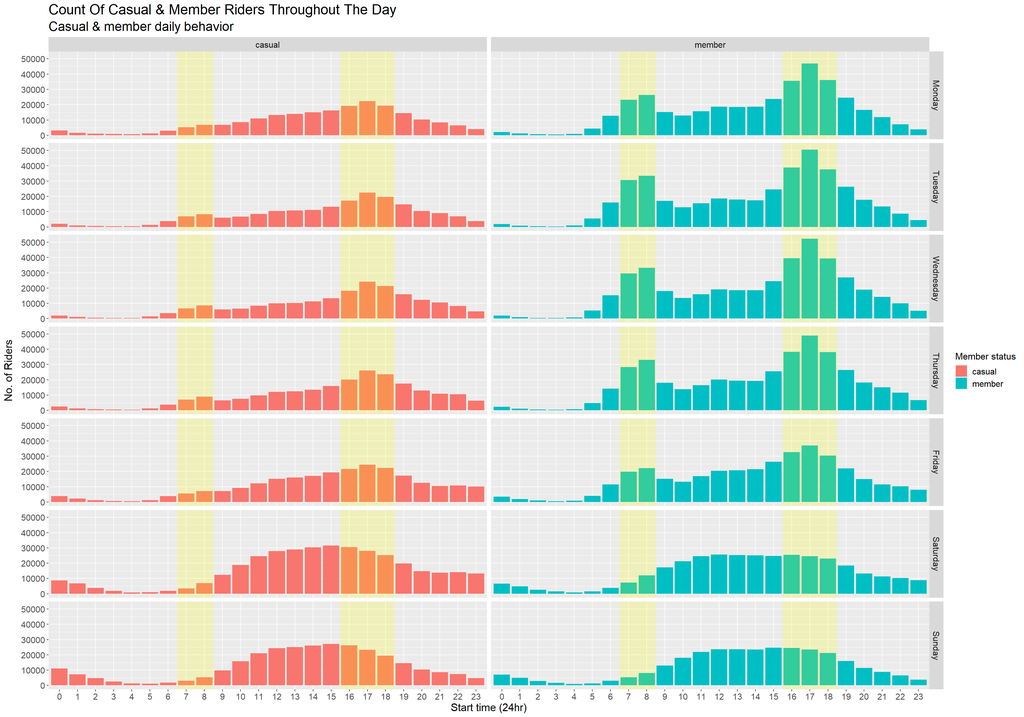

```r
ordered_time <- c(0:23)

biketrip_tb_r1_time %>%
  ggplot() +
  geom_bar(mapping = aes(x = factor(start_time_hr, ordered_time), fill = member_casual)) +
  facet_grid(~factor(start_day_of_week, c("Monday","Tuesday","Wednesday","Thursday","Friday","Saturday","Sunday")) ~member_casual) +
  labs(title = "Count Of Casual & Member Riders Throughout The Day",
       subtitle = "Casual & member daily behavior",
       fill = "Member status") +
  theme(axis.text = element_text(size = 12),
        axis.title = element_text(size = 15),
        axis.title.y = element_text(margin = margin(r = 10)),
        strip.text = element_text(size = 12),
        plot.title = element_text(size = 20),
        plot.subtitle =  element_text(size = 18),
        legend.title = element_text(size = 13),
        legend.text = element_text(size = 12)) +
  xlab("Start time (24hr)") +
  ylab("No. of Riders") +
  annotate("rect", xmin = c(7.5, 16.5), xmax = c(9.5, 19.5), ymin = -Inf, ymax = Inf, alpha = 0.2, fill = "yellow")
```

Chart 1.3 shows that:

- Casual riders:
  - Peaks around 5pm on weekdays while remaining low for the throughout the day.
  - Very active during the weekends where riders remains high from 11am to 6pm.
  - Casual riders are generally higher than member riders on weekends and lower on weekdays.
- Member riders:
  - Peaks around 8am and 5pm on weekdays while remaining low for the rest of the day.
  - No peak is observed at 8am during the weekends.
  - Remain constantly high from 11am to 6pm on weekends but generally lesser than the amount of casual riders.

The yellow highlighted peaks supports the hypothesize where member uses the bike for commuting where 8am is most likely when users ride to work, and 5pm when user ride back home.

Further exploration will be done to find out what casual riders uses the bike for.

### Chart 1.4: Monthly Count of Riders throughout the Year

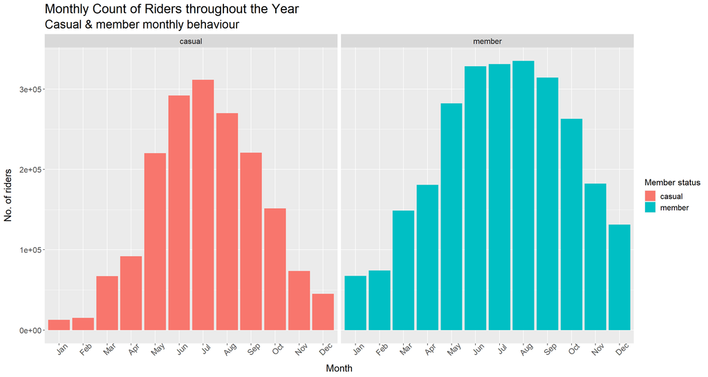

```r
biketrip_tb_r1 %>%
  ggplot() +
  geom_bar(mapping = aes(x = month(ymd_hms(started_at), label = TRUE), fill = member_casual)) +
  facet_wrap(~member_casual) +
  theme(axis.text.x = element_text(angle = 45),
        axis.text = element_text(size = 12),
        axis.title = element_text(size = 15),
        axis.title.y = element_text(margin = margin(r = 10)),
        strip.text = element_text(size = 12),
        plot.title = element_text(size = 20),
        plot.subtitle =  element_text(size = 18),
        legend.title = element_text(size = 13),
        legend.text = element_text(size = 12)) +
  labs(title = "Monthly Count of Riders throughout the Year",
       subtitle = "Casual & member monthly behaviour",
       fill = "Member status") +
  xlab("Month") +
  ylab("No. of riders")
```

Moving on, Chart 1.4 shows that the top 3 months with most active riders for both casual and member riders are from June to August. Based on the annual Chicago average temperature by NOAA (National Oceanic And Atmospheric Administration) shown below, June to August is also the top 3 warmest months throughout the year as it represents the Summer season in America.

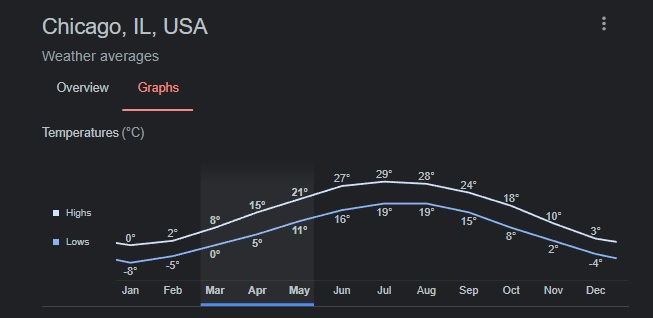

Hence, it can be said that there is a correlation between the temperature and amount of active rider where as the temperature gets warmer, the amount of rider gets larger.

## 2. Which is the preferred bike among users?

### Chart 2.1: Bike Preference Among Casual & Member Riders throughout the Week

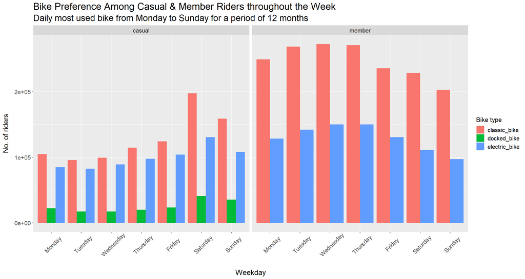

```r
biketrip_tb_r1 %>%
  ggplot() +
  geom_bar(mapping = aes(x = factor(start_day_of_week, c("Monday","Tuesday","Wednesday","Thursday","Friday","Saturday","Sunday")),
                         fill = rideable_type),
           position = "dodge") +
  facet_wrap(~member_casual) +
  theme(axis.text.x = element_text(angle = 45, margin = margin(t = 20)),
        axis.text = element_text(size = 12),
        axis.title = element_text(size = 15),
        axis.title.y = element_text(margin = margin(r = 10)),
        strip.text = element_text(size = 12),
        plot.title = element_text(size = 20),
        plot.subtitle =  element_text(size = 18),
        legend.title = element_text(size = 13),
        legend.text = element_text(size = 12)) +
  labs(title = "Bike Preference Among Casual & Member Riders throughout the Week",
       subtitle = "Daily most used bike from Monday to Sunday for a period of 12 months",
       fill = "Bike type") +
  xlab("Weekday") +
  ylab("No. of riders")
```

### Chart 2.2: Bike Preference Among Casual & Member Riders Throughout The Year

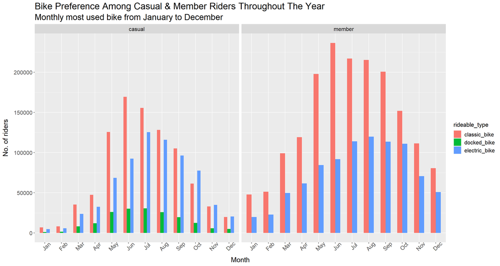

```r
biketrip_tb_r1 %>%
  ggplot() +
  geom_bar(mapping = aes(x = month(ymd_hms(started_at), label = TRUE),fill = rideable_type),
           width = 0.6,
           position = "dodge") +
  facet_wrap(~member_casual) +
  theme(axis.text.x = element_text(angle = 45),
        axis.text = element_text(size = 12),
        axis.title = element_text(size = 15),
        axis.title.y = element_text(margin = margin(r = 10)),
        strip.text = element_text(size = 12),
        plot.title = element_text(size = 20),
        plot.subtitle =  element_text(size = 18),
        legend.title = element_text(size = 13),
        legend.text = element_text(size = 12)) +
  labs(title = "Bike Preference Among Casual & Member Riders Throughout The Year",
       subtitle = "Monthly most used bike from January to December") +
  xlab("Month") +
  ylab("No. of riders")
```

- Classic bike remains as the most used bike among the casual and member riders, followed by electric bike and docked bike.
  - This may be due to using classic bike can be treated as a form of exercise and a healthier option compared to electric bike, and also not having to worry about battery running out.
  - Docked bike having the least preference may be due to not being as aesthetically pleasing and comfortable as compared to classical bike, even though it works the same as a classical bike.
    - Additional data will be needed to justify bike preference in a form of survey as current data is limited.

## 3. Where do users ride to the most?

### Chart & Table 3.1: Top 10 most visited locations for casual riders

```r
top_10_most_visit_loc_casual <- biketrip_tb_r1 %>%
  filter(member_casual == "casual") %>% # Filter table for casual riders only.
  mutate(route = paste(start_station_name, end_station_name, sep = " to ")) %>% # adding additional column route by concatenating start_station_name and end_station_name with separator "to".
  group_by(route) %>% #group by route for calculation
  summarise(casual_rider_count = n(), avg_ride_dur_min = round(mean(ride_duration_sec/60), digits = 2)) %>%  # summarizing casual rider count & ride duration in minutes.
  arrange(-casual_rider_count) %>%
  head(10)
```

```r
head(top_10_most_visit_loc_casual, 10)
```

```
## # A tibble: 10 × 3
##    route                                                         casua…¹ avg_r…²
##    <chr>                                                           <int>   <dbl>
##  1 Streeter Dr & Grand Ave to Streeter Dr & Grand Ave              10691    40.5
##  2 DuSable Lake Shore Dr & Monroe St to DuSable Lake Shore Dr &…    6766    34.7
##  3 DuSable Lake Shore Dr & Monroe St to Streeter Dr & Grand Ave     5254    28.4
##  4 Michigan Ave & Oak St to Michigan Ave & Oak St                   4652    45.3
##  5 Millennium Park to Millennium Park                               4106    37.4
##  6 Montrose Harbor to Montrose Harbor                               2950    49.6
##  7 Streeter Dr & Grand Ave to DuSable Lake Shore Dr & Monroe St     2892    28.1
##  8 Streeter Dr & Grand Ave to Millennium Park                       2775    33.6
##  9 Shedd Aquarium to Shedd Aquarium                                 2494    22.8
## 10 Shedd Aquarium to Streeter Dr & Grand Ave                        2448    33.2
## # … with abbreviated variable names ¹casual_rider_count, ²avg_ride_dur_min
```

```r
top_10_most_visit_loc_casual %>%
  summarise(avg_top10_ride_dur = mean(avg_ride_dur_min), max_top_10_ride_dur = max(avg_ride_dur_min), min_top_10_ride_dur = min(avg_ride_dur_min))
```

```
## # A tibble: 1 × 3
##   avg_top10_ride_dur max_top_10_ride_dur min_top_10_ride_dur
##                <dbl>               <dbl>               <dbl>
## 1               35.3                49.6                22.8
```

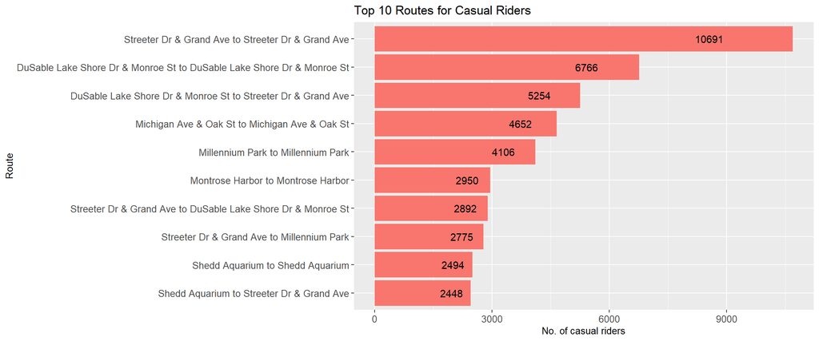

```r
# reordering route to show in descending order in chart to plot
top_10_most_visit_loc_casual$route <- factor(top_10_most_visit_loc_casual$route) %>%
  fct_reorder(top_10_most_visit_loc_casual$casual_rider_count)

top_10_most_visit_loc_casual %>%
  ggplot() +
  geom_col(mapping = aes(x = casual_rider_count, y = route, fill = "orange")) +
  geom_text(mapping = aes(x = casual_rider_count, y = route, label = casual_rider_count),
            position = position_stack(vjust = 0.8)) +
  labs(title = "Top 10 Routes for Casual Riders") +
  xlab("No. of casual riders") +
  ylab("Route") +
  theme(legend.position = "none",
        axis.title = element_text(size = 10),
        axis.text = element_text(size = 10))
```

### Chart & Table 3.2: Top 10 most visited routes for casual riders during the weekdays at 5pm peak

```r
top_10_most_visit_loc_casual_5pm <- biketrip_tb_r1_time %>%
  filter(member_casual == "casual") %>%
  filter(start_time_hr == 17) %>%
  filter((start_day_of_week != "Sunday") & (start_day_of_week != "Saturday")) %>%
  mutate(route = paste(start_station_name, end_station_name, sep = " to ")) %>%
  group_by(route) %>% #group by route for calculation
  summarise(casual_rider_count = n(), avg_ride_dur_min = round(mean(ride_duration_sec/60), digits = 2)) %>%
  arrange(-casual_rider_count) %>%
  head(10)

head(top_10_most_visit_loc_casual_5pm,10)
```

```
## # A tibble: 10 × 3
##    route                                                         casua…¹ avg_r…²
##    <chr>                                                           <int>   <dbl>
##  1 Streeter Dr & Grand Ave to Streeter Dr & Grand Ave                522   35.6
##  2 DuSable Lake Shore Dr & Monroe St to DuSable Lake Shore Dr &…     340   33.6
##  3 DuSable Lake Shore Dr & Monroe St to Streeter Dr & Grand Ave      269   35.7
##  4 Michigan Ave & Oak St to Michigan Ave & Oak St                    212   34.2
##  5 Millennium Park to Millennium Park                                172   33.3
##  6 Streeter Dr & Grand Ave to Michigan Ave & Oak St                  165   24.9
##  7 Streeter Dr & Grand Ave to DuSable Lake Shore Dr & Monroe St      159   22.0
##  8 Montrose Harbor to Montrose Harbor                                148   39.5
##  9 Streeter Dr & Grand Ave to Millennium Park                        146   31.0
## 10 Sheffield Ave & Fullerton Ave to Greenview Ave & Fullerton A…     142    5.19
## # … with abbreviated variable names ¹casual_rider_count, ²avg_ride_dur_min
```

```r
top_10_most_visit_loc_casual_5pm %>%
  summarise(avg_top10_ride_dur = mean(avg_ride_dur_min), max_top_10_ride_dur = max(avg_ride_dur_min), min_top_10_ride_dur = min(avg_ride_dur_min))
```

```
## # A tibble: 1 × 3
##   avg_top10_ride_dur max_top_10_ride_dur min_top_10_ride_dur
##                <dbl>               <dbl>               <dbl>
## 1               29.5                39.5                5.19
```

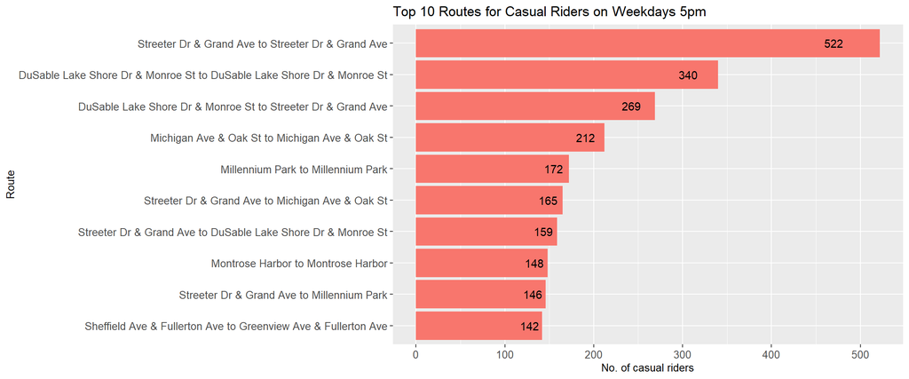

```r
# reordering route to show in descending order in chart to plot
top_10_most_visit_loc_casual_5pm$route <- factor(top_10_most_visit_loc_casual_5pm$route) %>%
  fct_reorder(top_10_most_visit_loc_casual_5pm$casual_rider_count)

top_10_most_visit_loc_casual_5pm %>%
  ggplot() +
  geom_col(mapping = aes(x = casual_rider_count, y = route, fill = "orange" )) +
  geom_text(mapping = aes(x = casual_rider_count, y = route, label = casual_rider_count),
            position = position_stack(vjust = 0.9)) +
  labs(title = "Top 10 Routes for Casual Riders on Weekdays 5pm") +
  xlab("No. of casual riders") +
  ylab("Route") +
  theme(legend.position = "none",
        axis.title = element_text(size = 10),
        axis.text = element_text(size = 10))
```

### Chart & Table 3.3: Top 10 most visited locations for member riders

```r
top_10_most_visit_loc_member <- biketrip_tb_r1 %>%
  filter(member_casual == "member") %>%
  mutate(route = paste(start_station_name, end_station_name, sep = " to ")) %>%
  group_by(route) %>%
  summarise(member_rider_count = n(), avg_ride_dur_min = round(mean(ride_duration_sec/60), digits = 2)) %>%
  arrange(-member_rider_count) %>%
  head(10)
```

```r
head(top_10_most_visit_loc_member,10)
```

```
## # A tibble: 10 × 3
##    route                                             member_rider_count avg_ri…¹
##    <chr>                                                          <int>    <dbl>
##  1 Ellis Ave & 60th St to University Ave & 57th St                 5947     4.93
##  2 University Ave & 57th St to Ellis Ave & 60th St                 5617     4.97
##  3 Ellis Ave & 60th St to Ellis Ave & 55th St                      5244     5.29
##  4 Ellis Ave & 55th St to Ellis Ave & 60th St                      4690     5.37
##  5 State St & 33rd St to Calumet Ave & 33rd St                     3222     4.76
##  6 Calumet Ave & 33rd St to State St & 33rd St                     3200     4.16
##  7 Loomis St & Lexington St to Morgan St & Polk St                 2865     5.26
##  8 Morgan St & Polk St to Loomis St & Lexington St                 2841     5.51
##  9 University Ave & 57th St to Kimbark Ave & 53rd St               2258     7.29
## 10 Loomis St & Lexington St to Halsted St & Polk St                2136     7.6
## # … with abbreviated variable name ¹avg_ride_dur_min
```

```r
top_10_most_visit_loc_member %>%
  summarise(avg_top10_ride_dur = mean(avg_ride_dur_min), max_top_10_ride_dur = max(avg_ride_dur_min), min_top_10_ride_dur = min(avg_ride_dur_min))
```

```
## # A tibble: 1 × 3
##   avg_top10_ride_dur max_top_10_ride_dur min_top_10_ride_dur
##                <dbl>               <dbl>               <dbl>
## 1               5.51                 7.6                4.16
```

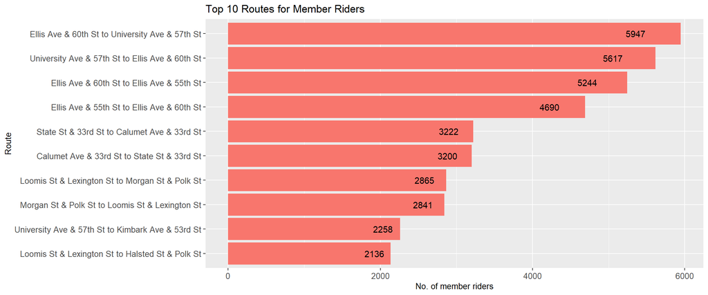

```r
# reordering route to show in descending order in chart
top_10_most_visit_loc_member$route <- factor(top_10_most_visit_loc_member$route) %>%
  fct_reorder(top_10_most_visit_loc_member$member_rider_count)

top_10_most_visit_loc_member %>%
  ggplot() +
  geom_col(mapping = aes(x = member_rider_count, y = route, fill = "orange" )) +
  geom_text(mapping = aes(x = member_rider_count, y = route, label = member_rider_count),
            position = position_stack(vjust = 0.9)) +
  labs(title = "Top 10 Routes for Member Riders") +
  xlab("No. of member riders") +
  ylab("Route") +
  theme(legend.position = "none",
        axis.title = element_text(size = 10),
        axis.text = element_text(size = 10))
```

### Chart & Table 3.4: Top 10 most visited routes for member riders during the weekdays at 8am & 5pm peak

```r
# Creating top 10 8am member route

top_10_member_loc_8am <- biketrip_tb_r1_time %>%
  filter(member_casual == "member") %>%
  filter(start_time_hr == 8) %>%
  filter((start_day_of_week != "Sunday") & (start_day_of_week != "Saturday")) %>%
  mutate(route = paste(start_station_name, end_station_name, sep = " to "), start_time_hr) %>%
  group_by(route, start_time_hr) %>%
  summarise(member_rider_count = n(), avg_ride_dur_min = round(mean(ride_duration_sec/60), digits = 2)) %>%
  arrange(-member_rider_count) %>%
  head(10)
# Creating top 10 5pm member route

top_10_member_loc_5pm <- biketrip_tb_r1_time %>%
  filter(member_casual == "member") %>%
  filter(start_time_hr == 17) %>%
  filter((start_day_of_week != "Sunday") & (start_day_of_week != "Saturday")) %>%
  mutate(route = paste(start_station_name, end_station_name, sep = " to "), start_time_hr) %>%
  group_by(route, start_time_hr) %>%
  summarise(member_rider_count = n(), avg_ride_dur_min = round(mean(ride_duration_sec/60), digits = 2)) %>%
  arrange(-member_rider_count) %>%
  head(10)
# Combining both top 10 8am & 5pm member route

top_10_member_weekday_5am_8pm_loc <- rbind(top_10_member_loc_8am, top_10_member_loc_5pm)

head(top_10_member_weekday_5am_8pm_loc,20)
```

```
## # A tibble: 20 × 4
## # Groups:   route [17]
##    route                                                 start…¹ membe…² avg_r…³
##    <chr>                                                   <int>   <int>   <dbl>
##  1 Canal St & Madison St to Michigan Ave & Washington St       8     227    6.72
##  2 Ellis Ave & 60th St to Ellis Ave & 55th St                  8     224    4.56
##  3 Ellis Ave & 55th St to Ellis Ave & 60th St                  8     221    4.96
##  4 Racine Ave & Wrightwood Ave to Sheffield Ave & Fulle…       8     212    3.19
##  5 LaSalle St & Jackson Blvd to Clark St & Randolph St         8     200    3.97
##  6 Ellis Ave & 60th St to University Ave & 57th St             8     197    5.08
##  7 Lake Park Ave & 56th St to University Ave & 57th St         8     189    5.69
##  8 Calumet Ave & 33rd St to State St & 33rd St                 8     186    3.7
##  9 Ellis Ave & 60th St to Ellis Ave & 58th St                  8     185    3.44
## 10 Cornell Ave & Hyde Park Blvd to University Ave & 57t…       8     182   10.2
## 11 University Ave & 57th St to Ellis Ave & 60th St            17     402    5.38
## 12 Ellis Ave & 60th St to University Ave & 57th St            17     321    4.13
## 13 Ellis Ave & 55th St to Ellis Ave & 60th St                 17     310    6.04
## 14 Ellis Ave & 60th St to Ellis Ave & 55th St                 17     265    9.1
## 15 State St & 33rd St to Calumet Ave & 33rd St                17     260    5.09
## 16 Morgan St & Polk St to Loomis St & Lexington St            17     246    6.02
## 17 Loomis St & Lexington St to Halsted St & Polk St           17     243    7.6
## 18 University Ave & 57th St to Lake Park Ave & 56th St        17     231    5.27
## 19 Ravenswood Ave & Lawrence Ave to Clark St & Winnemac…      17     219    4.45
## 20 Michigan Ave & Washington St to Clinton St & Washing…      17     197    6.74
## # … with abbreviated variable names ¹start_time_hr, ²member_rider_count,
## #   ³avg_ride_dur_min
```

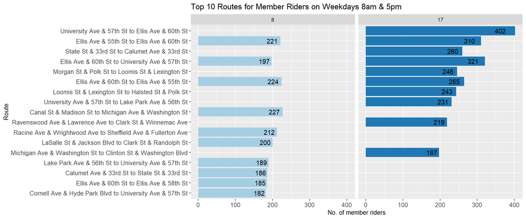

```r
# reordering route to show in descending order in chart to plot
top_10_member_weekday_5am_8pm_loc$route <- factor(top_10_member_weekday_5am_8pm_loc$route) %>%
  fct_reorder(top_10_member_weekday_5am_8pm_loc$member_rider_count)

top_10_member_weekday_5am_8pm_loc %>%
  ggplot() +
  geom_col(mapping = aes(x = member_rider_count, y = route, fill = factor(start_time_hr))) +
  geom_text(mapping = aes(x = member_rider_count, y = route, label = member_rider_count),
            position = position_stack(vjust = 0.9)) +
  facet_grid(~start_time_hr) +
  labs(title = "Top 10 Routes for Member Riders on Weekdays 8am & 5pm") +
  xlab("No. of member riders") +
  ylab("Route") +
  theme(legend.position = "none",
        axis.title = element_text(size = 10),
        axis.text = element_text(size = 10)) +
  scale_fill_brewer(palette = "Paired")
```

Finally, from Chart 3.1 and 3.2 shows that:

- Casual riders:
  - Are most active around tourists attractions with routes between:
    - Streeter Dr & Grand Ave = Navy Pier
    - DuSable Lake Shore = Buckingham Fountain
    - Millennium Park
    - Mantrose Harbor
    - Shedd Aquarium
  - Have a longer average ride duration of 35min among the top 10 routes taken.
  - Among the top 10 most visited area by casual riders during weekdays 5pm are local tourist attraction as well.
    - Locations suggest that these areas are highly anticipated for leisure and exercise.

## 4. Summary of analysis

*Note: Data is based on Chicago where standard U.S. business hours are 9am to 5pm, Monday through Friday.*

# Phase 6: **ACT**

## Recommendations

Business objective: **To convert casual riders into annual members**

*Note: Assuming the company already has their own Cyclistic bike share mobile application for used for subscription, bike location and duration tracking.*

- Create an accumulative point reward system (eg.: Cyclistic-coin), for members that cycle more than 30 minutes where Cyclistic-coin can be used to redeem other digital wallet credit or used directly.
  - As seen from the trends, the average ride duration of casual riders are about 35 minutes on average from the top 10 routes, and an average of 29 minutes from 5pm weekdays ride. Hence, implementing a point rewarding system may attract casual riders to subscribe for membership where they can earn and ride almost every day.
- Partner with F&Bs around tourist attraction spots where goods can be bought directly using Cyclistic-coin.
  - Since casual riders tend to ride around tourist attraction locations, buying snacks or drinks are anticipated to be a common thing to do. Hence, by becoming a member, they can then earn the Cyclistic-coin to purchase these goods instead.
  - Partnering with tourist attraction shops helps promote the Cyclistic membership scheme as well as helping out the business of these shops, a win-win scenario.
- Partnering with tourist attraction sites where Cyclistic member are entitled for discount during weekends and Summer.
  - Partnering with attraction sites such as the Navy Pier and Chicago’s Children Museum located at Streeter Dr & Grand Ave, Millenium Park Ice Rink at Millenium Park, and Shedd Aquarium where Cyclistic members are entitled for a discounted entrance fee during weekends and Summer, where both weekends and Summer are peak seasons for Cyclistic bike share.
- Create members weekly or monthly challenges for reward earning and increasing social media presence.
  - Challenges can be such as taking and posting a picture online of the bike at selected tourist attraction spot to earn Cyclistic-coin.
  - Posting pictures of Cyclistic bikes can help promote online presence.
  - Company can also validate and re-post pictures taken by users on selected social media platform to increase engagement.
- Organize cycling marathon during the summer.
  - Non-members who attend the cycling marathon will be offered a discounted rate on annual member subscription that will last until the following Summer, while members who participated can earn Cyclistic-coin and also be offered a discounted annual membership rate for the following year.
    - This create an opportunity to continuously organize cycling marathon with paid entrance fee every Summer and users are able to renew their annual membership and at discounted rate.
  - Big events such as this can attract a lot of attentions online and locally which amplifies advertising power to audiences.